# SCI Survey - Executive Summary

## Survey

- Survey applied between Aug 5th and Sept 19th, 2024, with 48 survey responses.
- Most respondents are White, with an overall balanced sample between male and female participants.

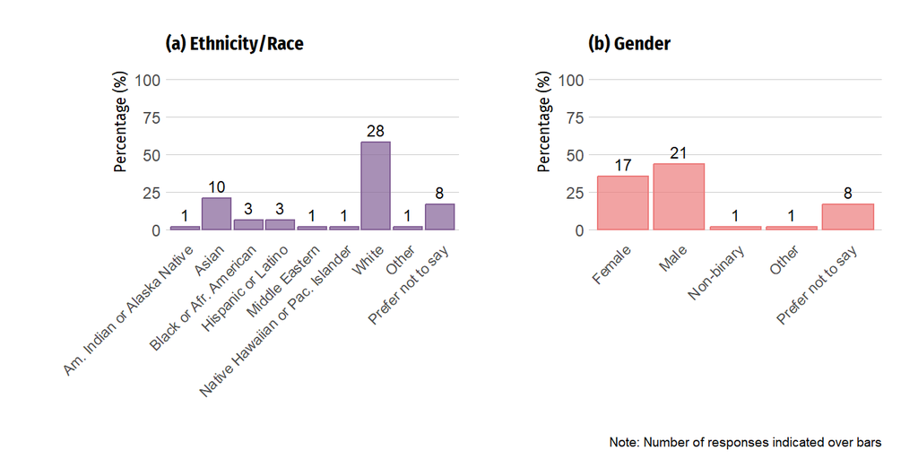

Figure 1: Distribution of demographic characteristics for survey respondents

## Reasons for (Non)Attendance

- 58.3% of respondents attended the last ACIC in Seattle.
- **Networking**, **dissemination** of one’s work, and **learning** about research are the top 3 most appealing factors for attending ACIC.
- In terms of barriers, **funding** was the most noted factor.

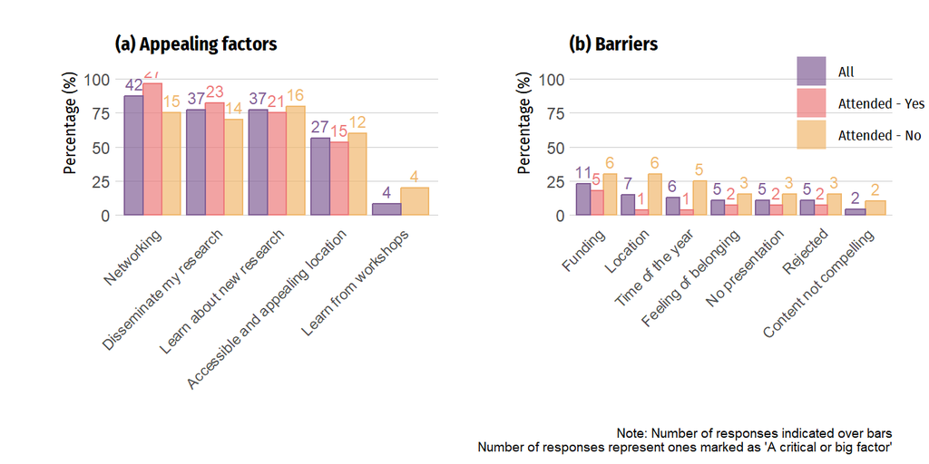

Figure 2: Appealing factors and barriers for ACIC 2024

## Experience at ACIC

- Attendants had a **good experience** in **Seattle** and **socializing**; however, experiences during **talks** and **short courses** were categorized **lower** than other aspects.
- Nearly half the respondents thought the talks were **too technical** (46.4%), and most think there should be **fewer**, **longer talks** (57.1%)

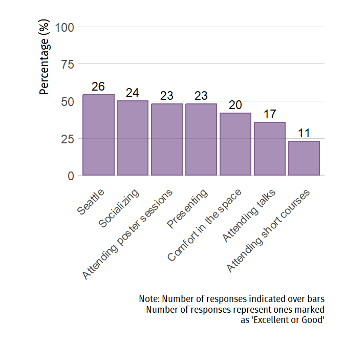

Figure 3: Experience at ACIC 2024

## Other Takeways

- Respondents report that program is **too theoretical** and technical, and want to see expansion on **applied work**.
- Some respondents feel there is **not enough diversity** in attendance, especially in underrepresented groups (e.g. Black/hispanic scholars, female scholars),
- **Inclusive** submission and review process.
- Additional spaces and opportunities for **networking** at the conference.